# UncoupledIsoReg usage guide

Jan Meis

2020-09-06

# The setting

You have uncoupled data of the form $x =\{x_1,...,x_n \}$, $Y=\{Y_1,...,Y_n \}$. The $x_i$ are fixed and known design points, for the sake of the example lets say equidistant on $[0, 1]$. The $Y_i$ are modeled by the equation

$$Y_i = m(x_i) + \varepsilon_i,$$
where $m:[0, 1] \rightarrow [-V, V]$ is an unknown, non-decreasing function and $\varepsilon_i \stackrel{iid}{\sim} \mathcal{D}$ are distributed according to some known error distribution, let’s say $\mathcal{D} = \text{Ber}$. Uncoupled data means that you do *not* know which $x_i$ belongs to which $Y_i$.

# The problem

Can we estimate produce an estimator $\hat m$ that estimates $m$?

# Representing the problem numerically

```r
library(UncoupledIsoReg)
n <- 1000
x <- seq(0, 1, length.out = n)
m <- function(x) (2*(x- 0.5))^3
Y_no_error <-  m(x)
varepsilon <- rbernoulli_custom(n, a=0.3, b= -0.3, p=0.5)
Y <- (Y_no_error + varepsilon) %>% sample(n)
dat <- tibble(x=x, Y=Y, Y_no_error = Y_no_error)
```

Let’s visualize our assumptions. This is $m$:

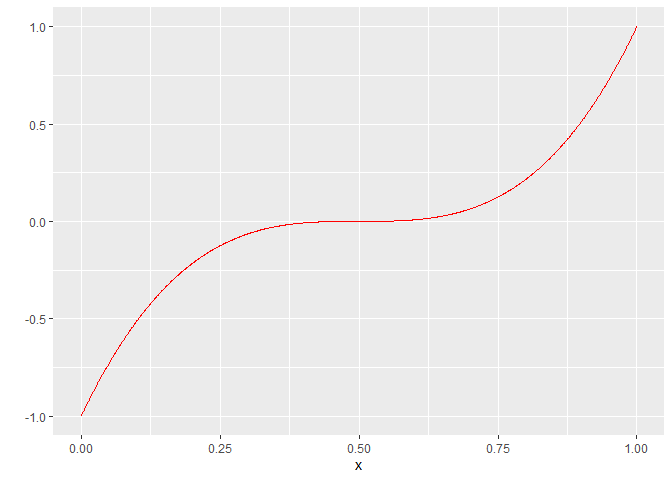

```r
ggplot(dat, aes(x=x, y=Y_no_error)) +
  geom_line(col="red") +
  scale_y_continuous("")
```

If we took the random ordering of $Y$ at face value, this would be what we would get:

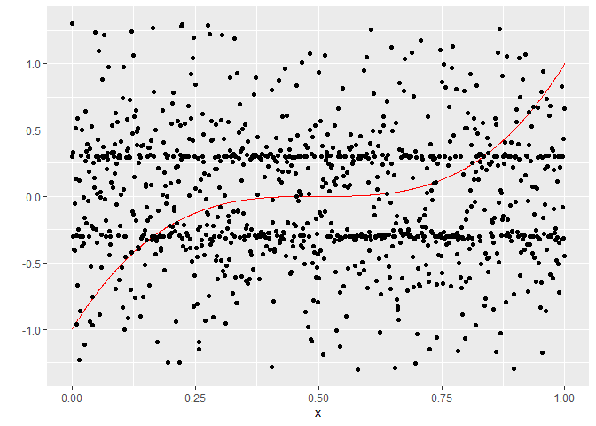

```r
ggplot(dat, aes(x=x, y=Y_no_error)) +
  geom_line(col="red") +
  scale_y_continuous("") +
  geom_point(aes(x=x, y=Y))
```

This is not really helpful though. It is a much better idea to imagine our information on $X$ as if it was projected on the x-axis, and the information on $Y$ as if it was projected on the y-axis:

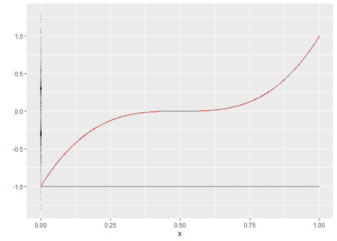

```r
ggplot(dat, aes(x=x, y=Y_no_error)) +
  geom_line(col="red") +
  scale_y_continuous("") +
  geom_point(aes(x=x, y=-1), size=0.8, alpha=0.05) +
  geom_point(aes(x=0, y=Y), size=0.8, alpha=0.05)
```

A naive - though as we will see not very useful - approach to get an “estimate” for $m$ would be to sort $Y$ in an increasing manner. This would at least lead to a montone function:

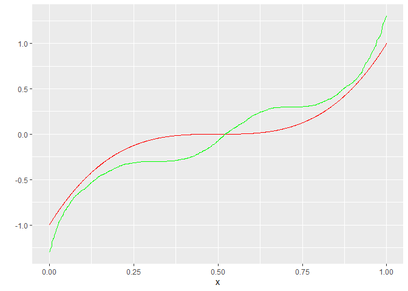

```r
Y_sorted <- sort(Y)
dat <- bind_cols(dat, Y_sorted=Y_sorted)

ggplot(dat, aes(x=x, y=Y_no_error)) +
  geom_line(col="red") +
  scale_y_continuous("") +
  geom_line(aes(y=Y_sorted), col="green")
```

This is terrible. But how can we do better? This is where Rigollet & Weed’s approach (Rigollet and Weed 2018) comes in: We want calculate

$$\hat{m} \in \operatorname{argmin}_{g \in F_V} \operatorname{W}_1(\pi_g \ast \mathcal{D}, \hat{\pi}).$$
For mathematical details, check out their paper (https://academic.oup.com/imaiai/article/8/4/691/5425686) and our vignette:

```r
vignette("numerical_considerations", package="UncoupledIsoReg")
```

# Using this package to calculate the estimator

There are two essential steps to calculating the minimum Wasserstein estimator with our package.

## Step 1: Calculate the “P” matrix

Our first goal is to discretize the domain of function over which we want to minimize. Roughly speaking, the domain `A` denotes a discretized version of the set of values, where we expect most of our values $Y$ to lie in. The number of points in this domain `N`. In our paper (yet to appear), we show that the rate of convergence of the minimum Wasserstein devoncolution estimator is $C n^{-1/(2p)}$, which makes $N = \sqrt n$ a somewhat natural choice.

```r
N <- round(sqrt(n))
N
```

```
#> [1] 32
```

```r
A <- seq(-1.3, 1.3, length.out = N)
stepsize <- (A[2]-A[1]) / 2
```

Since we know that the function $m$ can only take values in $[-1, 1]$, we can restrict this domain further to `A_V`. This will be set of values which the functions over which we minimize are allowed to take on.

```r
A_V <-  A[which(-1 - stepsize <= A & A <= 1 + stepsize)]
```

We can now define the `P` matrix, which is basically the Jacobian of the map $\mu \rightarrow \Pi_{\ast}^A (\mu \ast \mathcal{D}, \hat \pi)$, see the numerical vignette for a more in-depth explanation.

```r
p_ber <- function(x) pbernoulli_custom(x, a = -0.3, b = 0.3, p = .5)

P <- matrix(rep(0, times = (N) * length(A_V)), nrow = N)
P[1, ] <- p_ber(A[2] - stepsize - A_V)
for (i in 2:(N-1)) {
  P[i,] <- p_ber(A[i + 1] - stepsize - A_V) - p_ber(A[i] - stepsize - A_V)
}
P[N, ] <- 1 - p_ber(A[N] - stepsize - A_V)
```

This by the way is the step where our assumption that the error distribution is known comes into play (`p_ber`).

We are now ready to minimize!

# Step 2

We can now call the `minimize_entropic_W` function, which is a C++ function. The “entropic” in the function name signals that we do not actually minimize the Wasserstein distance, but an entropically regularized version of the Wasserstein distance.

I believe the Wasserstein distance (as opposed to the entropically regularized Wasserstein distance) in our problem might not be smooth, though i may be wrong.

```r
l <-
  minimize_entropic_W(Y = Y,
                      A = A,
                      AV = A_V,
                      P_D = P,
                      suppressOutput = T)
```

`minimize_entropic_W` returns a list. The items of this list we are most interested in are `vals` and `probs`. It is convenient to represent a discrete measure as a list containing a set of values and a set of probabilities associated with these values.

Lets call the measure produces by `minimize_entropic_W` $\hat mu$:

```r
mu_hat <- list()
mu_hat[["vals"]] <- l$vals
mu_hat[["probs"]] <- l$probs
```

We can convert this discrete measure to an isotonic function by calling the convenience function `measure_to_iso`:

```r
g_hat <- measure_to_iso(mu_hat, n)
```

Let’s look at our result!

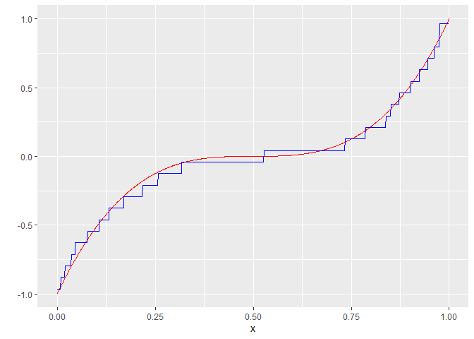

```r
dat <- bind_cols(dat, g_hat = g_hat)
ggplot(dat, aes(x=x, y=Y_no_error)) +
  geom_line(col="red") +
  scale_y_continuous("") +
  geom_line(aes(y=g_hat), col="blue")
```

Sometimes it may be a good idea to smooth the result:

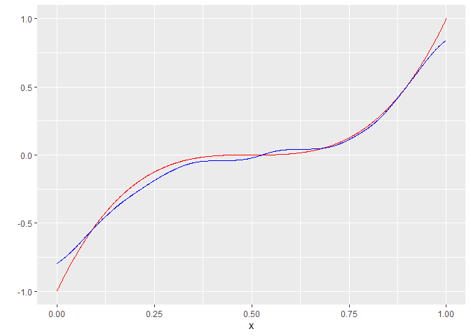

```r
g_hat_smooth <- ksmooth(x, g_hat, x.points = x, kernel="normal", bandwidth = 0.1)$y
dat <- bind_cols(dat, g_hat_smooth = g_hat_smooth)
ggplot(dat, aes(x=x, y=Y_no_error)) +
  geom_line(col="red") +
  scale_y_continuous("") +
  geom_line(aes(y=g_hat_smooth), col="blue")
```

The list `l` also saves some other interesting measures such as the Wasserstein distance of the final result.

```r
l$Best_W_val
```

```
#> [1] 0.02791118
```

This value is hard to evaluate however, since there is not really any comparison. The only point of reference we have is that smaller is better.

Since this a toy problem where we know the actual function $m$ behind the simulation, a useful measure to quantify the performance of the estimator might be the $L_p$ norm between $\hat g$ and $m$, i.e. $\left( \sum_{i=1}^n |\hat g (x_i) - m(x_i)|^p \right)^{1/p}$. We can compare this to e.g. the naive estimator restricted on $[-1, 1]$. The restriction on $[-1, 1]$ is a fair assumptions, because we also used this assumption in calcuating $\hat g$ (because we specified $A_V$).

```r
 sum( 1/n * (abs(g_hat - Y_no_error))^1 )
```

```
#> [1] 0.03562564
```

```r
Y_comparison <- Y_sorted
Y_comparison[Y_sorted<-1] <- -1
Y_comparison[Y_sorted>1] <- 1
sum( 1/n * (abs(Y_comparison - Y_no_error))^1 )
```

```
#> [1] 0.162063
```

We can also see how well the estimator performs if we don’t specify $A_V$:

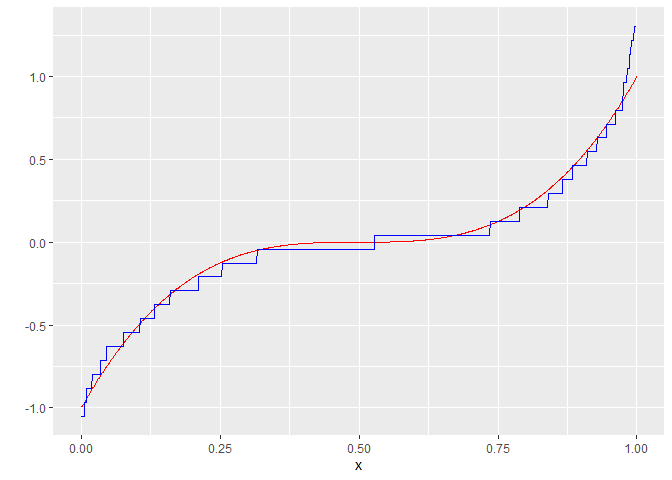

```r
P <- matrix(rep(0, times = (N) * length(A)), nrow = N)
P[1, ] <- p_ber(A[2] - stepsize - A)
for (i in 2:(N-1)) {
  P[i,] <- p_ber(A[i + 1] - stepsize - A) - p_ber(A[i] - stepsize - A)
}
P[N, ] <- 1 - p_ber(A[N] - stepsize - A)
l <-
  minimize_entropic_W(Y = Y,
                      A = A,
                      AV = A,
                      P_D = P,
                      suppressOutput = T)
mu_hat <- list()
mu_hat[["vals"]] <- l$vals
mu_hat[["probs"]] <- l$probs
g_hat <- measure_to_iso(mu_hat, n)
dat$g_hat <- g_hat
ggplot(dat, aes(x=x, y=Y_no_error)) +
  geom_line(col="red") +
  scale_y_continuous("") +
  geom_line(aes(y=g_hat), col="blue")
```

It works reasonably fine in this example, but specification of $A_V$ can save a lot of computation time. It is also way more relevant in situations where the domain of the noise distribution is unbounded.

# Other distributions

This package is not limited to discrete distributions. By defining the right `P` matrix, you can try to calculate Wasserstein deconvolution estimators for every distribution you can imagine.

Lets look at an example for the uniform distribution:

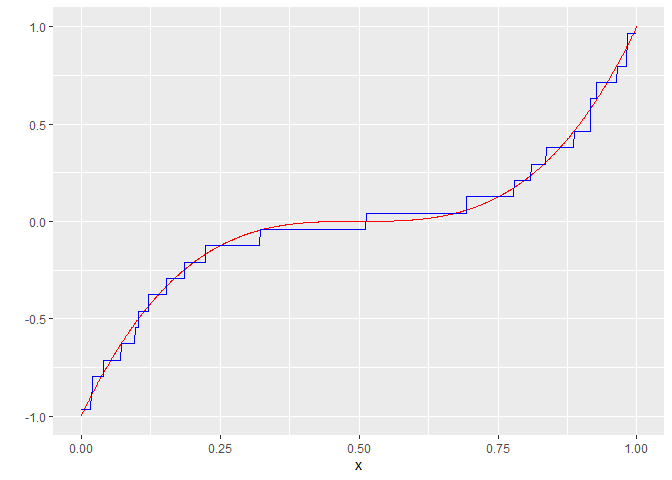

```r
n <- 1000
x <- seq(0, 1, length.out = n)
m <- function(x) (2*(x- 0.5))^3
Y_no_error <-  m(x)
varepsilon <- runif(n, min= -0.3, max= 0.3)
Y <- (Y_no_error + varepsilon) %>% sample(n)
dat <- tibble(x=x, Y=Y, Y_no_error = Y_no_error)
N <- round(sqrt(n))
A <- seq(-1.3, 1.3, length.out = N)
stepsize <- (A[2]-A[1]) / 2
A_V <-  A[which(-1 - stepsize <= A & A <= 1 + stepsize)]
p_unif <- function(x) punif(x, min = -0.3, max = 0.3)
P <- matrix(rep(0, times = (N) * length(A_V)), nrow = N)
P[1, ] <- p_unif(A[2] - stepsize - A_V)
for (i in 2:(N-1)) {
  P[i,] <- p_unif(A[i + 1] - stepsize - A_V) - p_unif(A[i] - stepsize - A_V)
}
P[N, ] <- 1 - p_unif(A[N] - stepsize - A_V)

l <-
  minimize_entropic_W(Y = Y,
                      A = A,
                      AV = A_V,
                      P_D = P,
                      suppressOutput = T)
mu_hat <- list()
mu_hat[["vals"]] <- l$vals
mu_hat[["probs"]] <- l$probs
g_hat <- measure_to_iso(mu_hat, n)
dat <- bind_cols(dat, g_hat = g_hat)
ggplot(dat, aes(x=x, y=Y_no_error)) +
  geom_line(col="red") +
  scale_y_continuous("") +
  geom_line(aes(y=g_hat), col="blue")
```

Though this is yet to be proven, the simulation results suggest that the minimum Wasserstein deconvolution estimator probably also convergences with a rate of $n^{-1/2}$ for the uniform distribution.

And for the normal distribution:

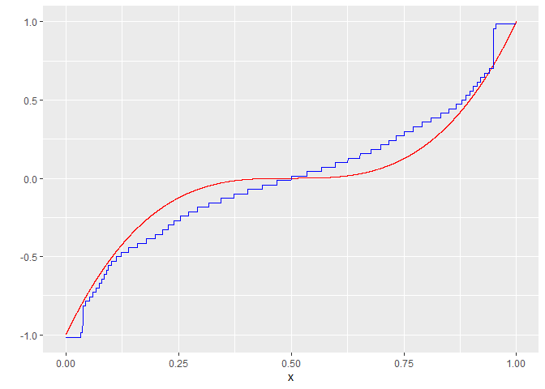

```r
n <- 10000
x <- seq(0, 1, length.out = n)
m <- function(x) (2*(x- 0.5))^3
Y_no_error <-  m(x)
varepsilon <- rnorm(n, mean = 0, sd=0.3)
Y <- (Y_no_error + varepsilon) %>% sample(n)
dat <- tibble(x=x, Y=Y, Y_no_error = Y_no_error)
N <- round(10*log(n))
A <- seq(-1.3, 1.3, length.out = N)
stepsize <- (A[2]-A[1]) / 2
A_V <-  A[which(-1 - stepsize <= A & A <= 1 + stepsize)]
p_unif <- function(x) punif(x, min = -0.3, max = 0.3)
P <- matrix(rep(0, times = (N) * length(A_V)), nrow = N)
P[1, ] <- p_unif(A[2] - stepsize - A_V)
for (i in 2:(N-1)) {
  P[i,] <- p_unif(A[i + 1] - stepsize - A_V) - p_unif(A[i] - stepsize - A_V)
}
P[N, ] <- 1 - p_unif(A[N] - stepsize - A_V)

l <-
  minimize_entropic_W(Y = Y,
                      A = A,
                      AV = A_V,
                      P_D = P,
                      suppressOutput = T)
mu_hat <- list()
mu_hat[["vals"]] <- l$vals
mu_hat[["probs"]] <- l$probs
g_hat <- measure_to_iso(mu_hat, n)
dat <- bind_cols(dat, g_hat = g_hat)
ggplot(dat, aes(x=x, y=Y_no_error)) +
  geom_line(col="red") +
  scale_y_continuous("") +
  geom_line(aes(y=g_hat), col="blue")
```

# Options

There are a log of knobs and levers to adjust in this algorithm. The function `min_entropic_W` allows the specification of many numerical parameters used in the minimization process. The help page, `?min_entropic_W`, offers a good starting point to learn about the mechanisms involved.

The numerical vignette offers some insight into reasonable choices for `A`.

# References

Rigollet, Philippe, and Jonathan Weed. 2018. “Uncoupled Isotonic Regression via Minimum Wasserstein Deconvolution.”